# Assignment02 VIS

jtang

9/23/2020

Referenced tutorials, Friday workshop, and Taelor’s example assignment throughout.

## Loading Libraries

```r
library(tidyverse)
library(dplyr)
library(ggplot2)
library(sf)
library(rnaturalearth)
library(ggspatial)
library(cartogram)
library(ggthemes)
library(gridExtra)
```

## Projections

**Basic Map**

```
## Scale on map varies by more than 10%, scale bar may be inaccurate
```

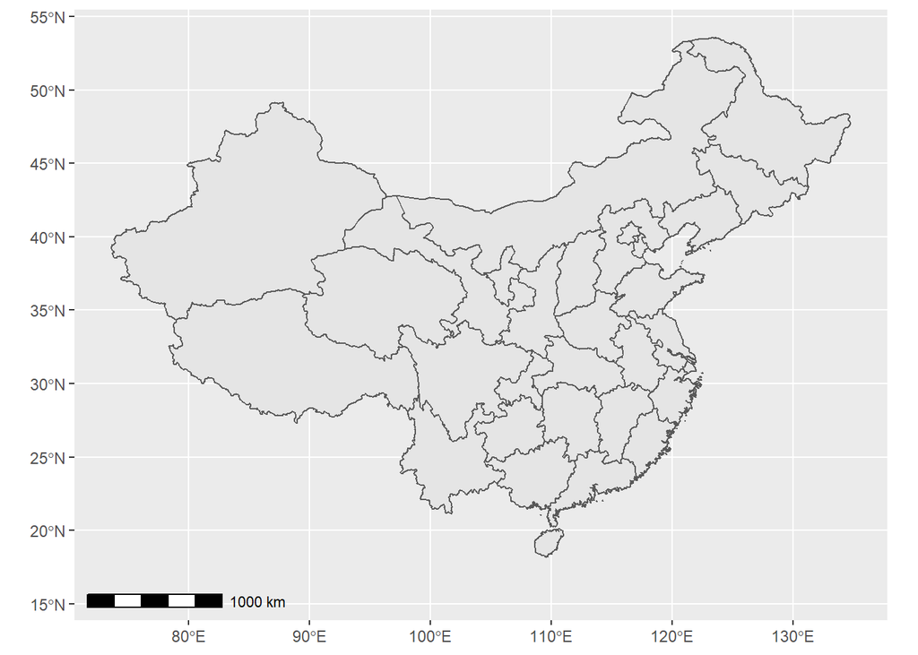

```r
china_provinces <- ne_states(country = "china", returnclass = "sf")

china_map <- ggplot(china_provinces) +
  geom_sf() +
  annotation_scale()

china_map
```

**Defining Projections**

```r
china_SRORG7564 <- "+proj=aea +lat_1=27 +lat_2=45 +lat_0=35 +lon_0=105 +x_0=0 +y_0=0 +ellps=WGS84 +datum=WGS84 +units=mm +no_defs"

china_EPSG2401 <- "+proj=tmerc +lat_0=0 +lon_0=75 +k=1 +x_0=25500000 +y_0=0 +ellps=krass +units=m +no_defs"

china_SRORG7271 <- "+proj=aea +lat_1=29.5 +lat_2=45.5 +lat_0=23 +lon_0=-96 +x_0=0 +y_0=0 +ellps=clrk66 +units=m +no_defs"
```

**China Albers Equal Area Conic**

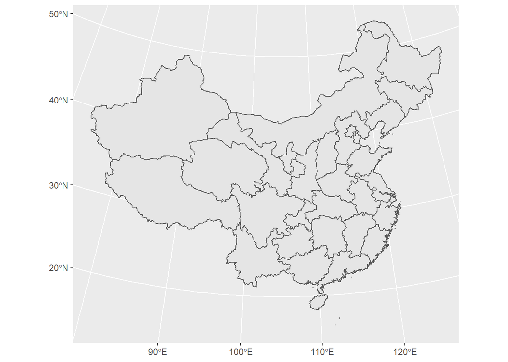

```r
ggplot(china_provinces) +
  geom_sf() +
  coord_sf(crs = china_SRORG7564)
```

**Beijing 1954 / 3-degree Gauss-Kruger zone 25**

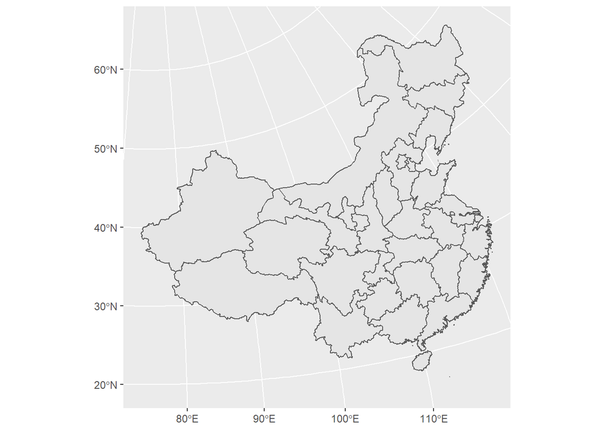

```r
ggplot(china_provinces) +
  geom_sf() +
  coord_sf(crs = china_EPSG2401)
```

**Contiguous United States Albers Equal Area**

Just wanted to see what this looked like.

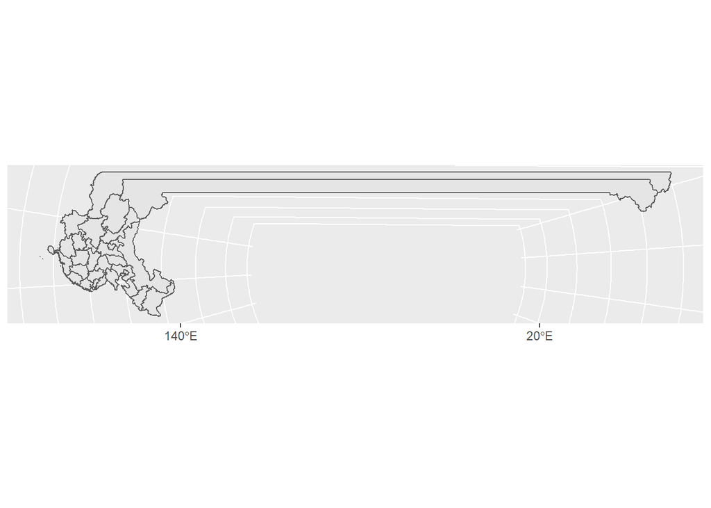

```r
ggplot(china_provinces) +
  geom_sf() +
  coord_sf(crs = china_SRORG7271)
```

**Transforming with China Albers Equal Area Conic**

Ended up picking this transformation.

```r
china_provinces <- china_provinces %>%
  st_transform(crs = china_SRORG7564)
```

## Gathering Data

I looked for province-level data I could find on China. I chose [2014 education attainment data](https://chinapower.csis.org/data/education-attainment-province/) from the Center for Strategic and International Studies, who had gotten the data from the China National Bureau of Statistics / China Statistical Yearbook.

Tidying education attainment data:

- percentage signs –> no percentage signs
- character –> numeric. Used `str()` to check structure

I transformed a lot of the data but ended up only using the percentages of females and males who went to college. Also, I did a simple female_college + male_college to get total percentage of population in that province who went to college.

```r
china_edu <- read_csv("china_educational-attainment.csv", col_names = TRUE) %>%
  rename (postal = code) %>%
  mutate(female_never = as.numeric(sub("%", "", female_never)),
         male_never = as.numeric(sub("%", "", male_never)),
         female_primary = as.numeric(sub("%", "", female_primary)),
         male_primary = as.numeric(sub("%", "", male_primary)),
         female_junior = as.numeric(sub("%", "", female_junior)),
         male_junior = as.numeric(sub("%", "", male_junior)),
         female_senior = as.numeric(sub("%", "", female_senior)),
         male_senior = as.numeric(sub("%","",male_senior)),
         female_college = as.numeric(sub("%", "", female_college)),
         male_college = as.numeric(sub("%", "", male_college)),
         college = female_college + male_college)

china_edu_join <- left_join(china_provinces, china_edu, by = "postal") %>%
  select(name,
         female_never,
         male_never,
         female_primary,
         male_primary,
         female_junior,
         male_junior,
         female_senior,
         female_college,
         male_college,
         college) %>%
  filter(!name == "Paracel Islands")
```

## Plotting Data

### Chloropleth

I wanted to compare % of Females in College with % of Males in College by province, so I installed the `gridExtra` package to place two plots side-by-side. I got suggestion from [here](https://stackoverflow.com/questions/1249548/side-by-side-plots-with-ggplot2).

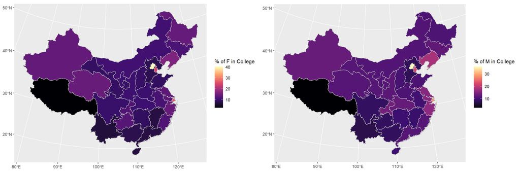

```r
female_college_plot <- ggplot(china_edu_join,
                                 aes(fill = female_college)) +
  geom_sf(color = "gray") +
  scale_fill_viridis_c(option = "magma",
                       name = "% of F in College",
                       breaks = seq(0, 100, by = 10))


male_college_plot <- ggplot(china_edu_join,
                               aes(fill = male_college)) +
  geom_sf(color = "gray") +
  scale_fill_viridis_c(option = "magma",
                       name = "% of M in College",
                       breaks = seq(0, 100, by = 10))


grid.arrange(female_college_plot, male_college_plot, nrow = 1, ncol = 2)
```

### Proportional symbol

(I originally wanted to put female_college first and male_college over it, and perhaps shift one over in case the color overlap was confusing. But the legends also ended up overlapping so I aborted mission. Carole said the tutorial for next week will cover layering of data, so I will try to figure this out then.)

```r
china_edu_centroids <- china_edu_join %>%
  st_centroid()
```

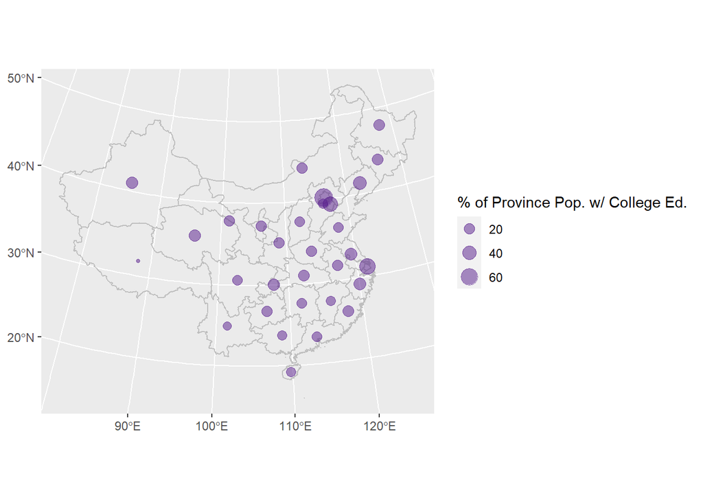

```r
ggplot(china_provinces) +
  geom_sf(fill = NA, color = "gray") +
  geom_sf(data = china_edu_centroids,
          aes (size = college),
          alpha = 0.5,
          color = "purple4") +
  scale_size_continuous(name = "% of Province Pop. w/ College Ed.",
                        breaks = seq(0, 100, by = 20))
```

### Continuous cartogram

I used % of Pop. w/ College Ed. for the shape and fill. These choices resulted in China’s rooster shape looking like it’s choking. Not sure about the story behind the empty chunk below the beige + pink–maybe that’s just how the sizing worked out.

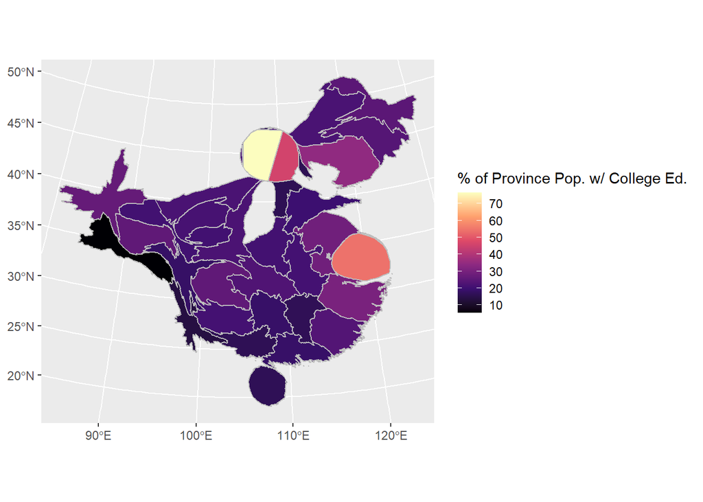

```r
china_edu_carto <- china_edu_join %>%
  cartogram_cont("college")

ggplot(china_edu_carto,
       aes(fill = college)) +
  geom_sf(color = "gray") + #(to change line size, size = x)
  scale_fill_viridis_c(option = "magma",
                       name = "% of Province Pop. w/ College Ed.",
                       breaks = seq(0, 100, by = 10))
```

### Non-continuous cartogram

Not very effective. Provinces are too small and I don’t think one can tell the country.

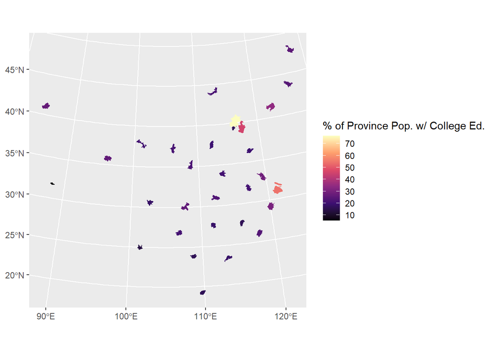

```r
china_edu_ncarto <- china_edu_join %>%
  cartogram_ncont("college")

ggplot(china_edu_ncarto,
       aes(fill = college)) +
  geom_sf(color = NA) +
  scale_fill_viridis_c(option = "magma",
                       name = "% of Province Pop. w/ College Ed.",
                       breaks = seq(0, 100, by = 10))
```

### Dorling cartogram

Looks more effective than the proportional symbol map, but with this one, one cannot tell one is looking at China nor what provinces to which dots. I may look into how to underlay a regular map of an area using the upcoming tutorial.

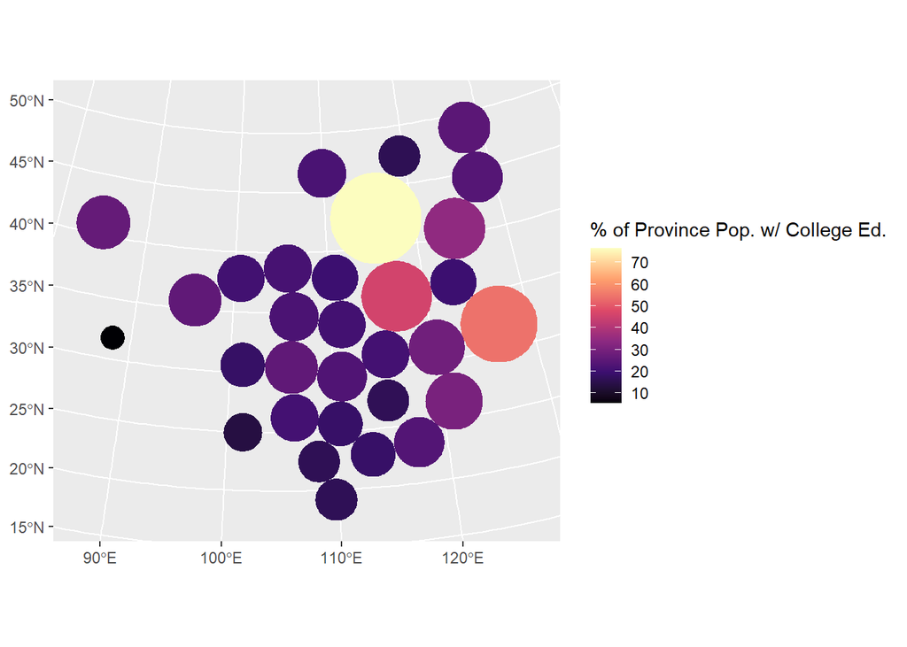

```r
china_edu_dor <- china_edu_join %>%
  cartogram_dorling("college")

ggplot(china_edu_dor,
       aes(fill = college)) +
  geom_sf(color = NA) +
  scale_fill_viridis_c(option = "magma",
                       name = "% of Province Pop. w/ College Ed.",
                       breaks = seq(0, 100, by = 10))
```